# Lesson 151 · Portfolio entry 1: entity classification

## 3 · Freeze the selection before test evaluation

We run two distinct procedures. The **reference track** keeps the published trial recipe and seeds 0–4. The **selected course track** first searches three learning rates using seed 100, then evaluates the chosen rate with seeds 10–14. Each run uses all data and all 20 epochs.

For each fit, the first strict maximum of validation AUROC selects its checkpoint. For the three candidate fits, the highest checkpoint-selection AUROC wins; the lower learning rate breaks an exact tie. Search loads only train and validation task tables. The frozen artifact contains the candidate result hashes, selected rate and future evaluation seeds.

**Worked example.** Candidate rates A and B both score `0.71` on validation, while C scores `0.70`. The smaller rate among A and B wins. A later test score cannot change that choice. The interaction below uses illustrative values; it is not an additional measured experiment.

Illustrative A=.70, B=.71, C=.71: B wins by lower-rate tie break. With any candidate missing, the choice is INCOMPLETE.

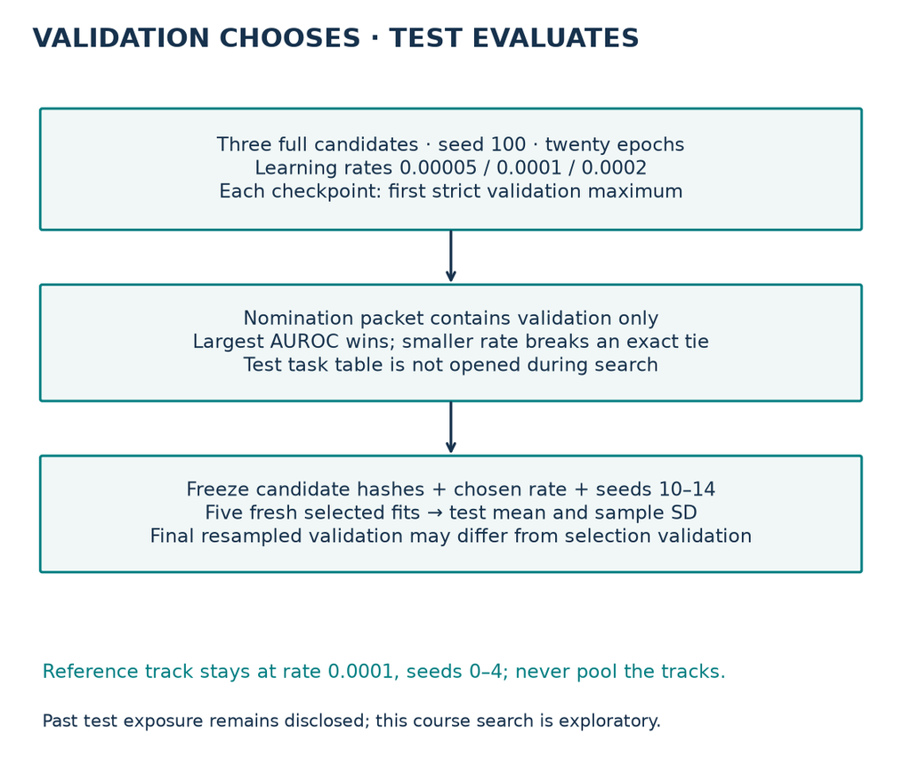

Three validation-only candidates, a hash-frozen choice, then five fresh selected fits. Scroll horizontally on narrow screens.

**Lab task 1 — `select_candidate`.** Reject incomplete or test-contaminated candidate packets, then implement the declared choice. Immediate checks include ties, missing candidates and nonfinite values. The full notebook reproduction calls your function when freezing its choice.

| Learning rate | Checkpoint-selection validation AUROC points |
| --- | --- |
| 5e-05 | 68.045336 |
| 0.0001 | 68.288815 |
| 0.0002 | 68.072588 |

Frozen course choice: **0.0001**. Search seed 100 is excluded from both primary means.

The search returned the reference learning rate. Both refit groups therefore use the same model recipe. Their separate seed sets retain distinct reporting roles; a score difference is not a tuning gain.

Final validation is reevaluated with freshly sampled neighborhoods after checkpoint selection. Its score can differ from the score that selected the checkpoint. Preserve both numbers rather than silently substituting one for the other.

> **Scope check.** Earlier lessons already evaluated this test population. The new course search is exploratory despite avoiding test access during this run. Its selected result remains a separate, search-nominated entry. Even if the search returns the reference learning rate, do not relabel or pool the preregistered tracks.

```python
# TODO: used in the real evidence report and fresh full gate.
def select_candidate(rows):
    """Exactly three predeclared candidates; first-validation-maximum scores only."""
    if len(rows)!=3 or {r['lr'] for r in rows}!={.00005,.0001,.0002}:
        raise ValueError('Require all three distinct planned learning rates')
    for r in rows:
        if r['split']!='val' or r['seed']!=100 or r['epochs']!=20 or not r['complete']:
            raise ValueError('Incomplete or wrong selection protocol')
        if any('test' in k.lower() for k in r):raise ValueError('Test information in selection packet')
        if not math.isfinite(r['selection_auc']) or not 0<=r['selection_auc']<=1:raise ValueError('Invalid validation score')
    return min(rows,key=lambda r:(-r['selection_auc'],r['lr']))['lr']
```

```python
# CHECK: run unchanged.
def rejects(fn):
    try:fn()
    except (ValueError,AssertionError):return
    raise AssertionError('Invalid evidence accepted')
def check_select(fn):
    rows=[dict(lr=lr,seed=100,epochs=20,complete=True,split='val',selection_auc=auc) for lr,auc in [(.00005,.70),(.0001,.71),(.0002,.71)]]
    assert fn(rows)==.0001,'Use validation maximum and lower-rate tie break'
    rejects(lambda:fn(rows[:2]));rejects(lambda:fn([dict(r,test_auc=.99) for r in rows]))
    rejects(lambda:fn([dict(r,complete=False) for r in rows]));rejects(lambda:fn([dict(r,selection_auc=float('nan')) for r in rows]))
check_select(select_candidate)
print("PASS select_candidate")
```

```
PASS select_candidate
```

## 4 · Collect every seed before summarizing

> **In plain terms.** A complete experiment includes the inconvenient seed. If you summarize only the outputs that arrived first, you change the experiment after seeing its outcome.

A **seed** controls stochastic initialization and sampling. Report all five completed seeds, their mean and **sample standard deviation**, which divides squared deviations by `n−1`. The reference and selected tracks use different seed sets, so their difference is not a paired causal estimate of the learning-rate change. This spread measures training-run variation on this task. It is not a confidence interval for performance across future databases or future years.

**Average seed metrics; do not pool their score scales.** Suppose two fitted models score the same negative and positive query using these logits:

| Fit | Negative | Positive | AUROC |
| --- | --- | --- | --- |
| A | 0 | 1 | 1 |
| B | 10 | 11 | 1 |

Mean seed AUROC is 1. If you instead concatenate the four observations, AUROC falls to 0.75: the positive score 1 from A loses to the negative score 10 from B. That comparison never occurred within either fitted model. Adding a constant to all logits in one fit preserves its ranking, so differences in score location cannot justify pooling across fits. The repeated query identities are another reason those four observations are not four independent test queries. Forming an ensemble by combining predictions per query is a separate, explicitly defined procedure.

**Try it after the example.** Subtract 10 from both scores of fit B. What changes in each seed's AUROC and in the pooled calculation?

**Check your reasoning**

Both seed AUROCs remain 1, but the pooled value becomes 1. A harmless within-fit shift changed the pooled answer, revealing why it is not the requested mean-over-fits statistic.

**Lab task 2 — `summarize_track`.** Require exactly the five planned unique seeds, the correct track and 20 completed epochs. Reject mixed search and evaluation runs. Calculate mean and sample SD only after those checks.

Predict before reading: what evidence supports complete fresh training?

| Procedure | Validation AUROC points | Test AUROC points | Fixed-recipe score gate |
| --- | --- | --- | --- |
| Published RDL | 68.18 ± 0.49 | 68.60 ± 1.01 | Published target |
| Reference, five fresh fits | 67.696425 ± 0.482609 | 69.258775 ± 0.748950 | CLOSE |
| Selected, five fresh fits | 67.789617 ± 0.239938 | 68.457012 ± 1.350223 | INCOMPARABLE |

Mean ± sample SD; the published standard deviation uses the authors’ reporting convention. All primary fits use the full released task.

| Track | Seed | Validation | Test |
| --- | --- | --- | --- |
| reference | 0 | 68.374144 | 69.991404 |
| reference | 1 | 67.720996 | 68.246098 |
| reference | 2 | 67.875125 | 69.043987 |
| reference | 3 | 67.416759 | 70.012592 |
| reference | 4 | 67.095100 | 68.999794 |
| selected | 10 | 67.866636 | 69.553715 |
| selected | 11 | 68.034614 | 66.597654 |
| selected | 12 | 67.831343 | 68.115942 |
| selected | 13 | 67.388167 | 68.032400 |
| selected | 14 | 67.827322 | 69.985350 |

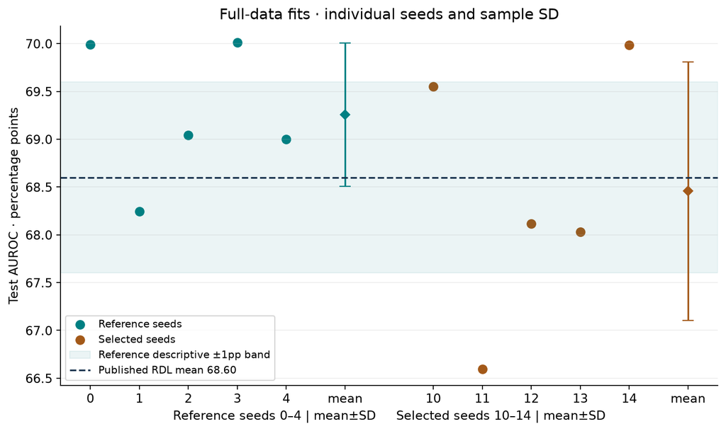

Measured individual seed AUROCs and mean with sample SD. The tolerance band applies only to the reference protocol. Scroll horizontally on narrow screens.

The frozen reference tolerance is ±1 AUROC percentage point around the published test mean `68.60`. This is a descriptive closeness rule. Passing it is not statistical equivalence or historical identity. The selected course track remains `INCOMPARABLE` for the preregistered reference gate even if it lands in the numerical band. This reporting boundary does not mean AUROC itself has different units.

```python
# TODO: used in the real evidence report and fresh full gate.
def summarize_track(rows,track,expected_seeds):
    """No checkpoint inference, missing fit, duplicate seed or mixed track allowed."""
    seeds=[r['seed'] for r in rows]
    if len(set(expected_seeds))!=5 or len(seeds)!=5 or set(seeds)!=set(expected_seeds):
        raise ValueError('Require exactly the five planned seeds')
    if track not in ('reference','selected'):raise ValueError('Unknown primary training track')
    for r in rows:
        if r['track']!=track or not r['complete'] or r['epochs']!=20:raise ValueError('Not a complete primary fit')
        if not math.isfinite(r['test_auc']) or not 0<=r['test_auc']<=1:raise ValueError('Invalid test score')
    values=[r['test_auc'] for r in sorted(rows,key=lambda r:r['seed'])]
    return dict(track=track,seeds=sorted(seeds),values=values,mean=statistics.mean(values),sample_sd=statistics.stdev(values))
```

```python
# CHECK: run unchanged.
def rejects(fn):
    try:fn()
    except (ValueError,AssertionError):return
    raise AssertionError('Invalid evidence accepted')
def check_summary(fn):
    rows=[dict(seed=s,track='reference',complete=True,epochs=20,test_auc=.66+.01*s) for s in range(5)]
    r=fn(rows,'reference',list(range(5)));assert abs(r['mean']-.68)<1e-12
    assert abs(r['sample_sd']-math.sqrt(.00025))<1e-12
    rejects(lambda:fn(rows[:4],'reference',list(range(5))))
    rejects(lambda:fn(rows[:4]+[rows[0]],'reference',list(range(5))))
    rejects(lambda:fn([dict(r,track='search') for r in rows],'reference',list(range(5))))
    rejects(lambda:fn([dict(r,epochs=19) for r in rows],'reference',list(range(5))))
check_summary(summarize_track)
print("PASS summarize_track")
```

```
PASS summarize_track
```

## 5 · Attach verification to the claim

**Lab task 3 — `portfolio_verdict`.** Separate protocol completeness, fixed-recipe score closeness, historical identity, fresh FE comparison and learner defense. A high score must not fill missing evidence fields.

All **13,779 labels** were independently reconstructed and compared with released SQL. All **20,730 saved predictions** across ten primary fits and three validation-only candidates were aligned to archive query keys and rescored. The sampler audited **3,388,770 query occurrences** with zero future-timestamp violations. Six load-bearing source definitions match the pinned implementation; each fit also passed a real-batch original-model comparison.

First-training-batch nonfinite-gradient counts range from **256 to 256** across runs. A separate source differential at seed0’s selected checkpoint checked **813 gradient tensors**, matching **256 nonfinite entries**, with maximum finite-entry difference **8.38e-09**. These observations must travel with the result: source agreement is not evidence of gradient health.

The notebook independently aligns every saved prediction by query key, recomputes AUROC using rank concordance, checks it against the official evaluation, and feeds the results through your live functions. This default path audits **author-reference evidence**. The post-EXIT full gate performs fresh training and exports a separate own-run report. The two paths never share an ownership label.

The paper reports a raw entity-table LightGBM baseline of `70.09 ± 1.41` test AUROC points for this task. That cited result is useful counter-evidence; it is not a freshly trained comparator in this lesson and it is not a manual relational-FE experiment. [Table 6](https://arxiv.org/html/2407.20060v1#A2.T6)

> **Scope check.** This entry establishes what ran and what was measured. It does not establish that RDL beats manual feature engineering, reproduces every paper task, or has been mastered by the learner. Those claims need their own evidence.

```python
# TODO: used in the real evidence report and fresh full gate.
def portfolio_verdict(track,protocol_ok,mean,defense_passed):
    """A tuned course result cannot pass the released-protocol reproduction gate."""
    if track not in ('reference','selected') or not math.isfinite(mean) or not 0<=mean<=1:
        raise ValueError('Require primary track and AUROC in [0,1]')
    score='INCOMPARABLE'
    if protocol_ok and track=='reference':score='CLOSE' if abs(mean-.686)<=.01+1e-12 else 'OUTSIDE_TOLERANCE'
    return dict(protocol='PASS' if protocol_ok else 'FAIL',paper_score=score,historical_identity='NOT_ESTABLISHED',fresh_fe_comparison='NOT_RUN',learner='DEFENDED' if defense_passed else 'PENDING_WRITTEN_DEFENSE')
```

```python
# CHECK: run unchanged.
def rejects(fn):
    try:fn()
    except (ValueError,AssertionError):return
    raise AssertionError('Invalid evidence accepted')
def check_entry(fn):
    r=fn('reference',True,.686,False)
    assert r['paper_score']=='CLOSE' and r['learner']=='PENDING_WRITTEN_DEFENSE'
    assert r['historical_identity']=='NOT_ESTABLISHED' and r['fresh_fe_comparison']=='NOT_RUN'
    assert fn('reference',True,.71,False)['paper_score']=='OUTSIDE_TOLERANCE'
    assert fn('selected',True,.686,False)['paper_score']=='INCOMPARABLE'
    assert fn('reference',False,.686,False)['paper_score']=='INCOMPARABLE'
    rejects(lambda:fn('reference',True,68.6,False))
check_entry(portfolio_verdict)
print("PASS portfolio_verdict")
```

```
PASS portfolio_verdict
```

```python
# CHECK: your live contracts process all author predictions, not fixture-only inputs.
rows=[];rng=np.random.default_rng(151)
for record in AUTHOR_SUMMARY['records']:
    phase=record['phase'];splits=['val'] if record['track']=='search' else ['val','test']
    for split in splits:
        prefix=phase+'_'+split+'_';keys=list(zip(DATA[prefix+'study'],DATA[prefix+'time']))
        order=rng.permutation(len(keys))
        score=keyed_auc(keys,DATA[prefix+'target'],[keys[i] for i in order],DATA[prefix+'pred'][order])
        assert abs(score-record[split+'_auc'])<1e-12
        rows.append(dict(lane=phase,split=split,auc=score,queries=len(keys)))
assert select_candidate(AUTHOR_SUMMARY['search']['candidates'])==AUTHOR_SUMMARY['search']['lr']
report_tracks={}
for track,seeds in [('reference',list(range(5))),('selected',list(range(10,15)))]:
    records=[dict(r,test_auc=next(x['auc'] for x in rows if x['lane']==r['phase'] and x['split']=='test')) for r in AUTHOR_SUMMARY['records'] if r['track']==track]
    report_tracks[track]=summarize_track(records,track,seeds)
    assert report_tracks[track]['mean']==AUTHOR_SUMMARY['tracks'][track]['mean']
    report_tracks[track]['verdict']=portfolio_verdict(track,True,report_tracks[track]['mean'],False)
    assert report_tracks[track]['verdict']==AUTHOR_SUMMARY['tracks'][track]['verdict']
for phase,history in AUTHOR_SUMMARY['histories'].items():
    assert len(history)==20 and all(x['queries']==11994 for x in history)
for examples in LABEL_EXAMPLES.values():
    for row in examples:assert trial_target(row['start'],row['analyses'],0)==(True,row['target'])
assert sum(r['queries'] for r in rows)==AUTHOR_SUMMARY['verified_predictions']
display(pd.DataFrame(rows))
portfolio_entry=dict(protocol=json.loads(SOURCES['protocol.json']),candidate_selection=AUTHOR_SUMMARY['search'],artifact_hashes=AUTHOR_SUMMARY['hashes'],audit=dict(labels=13779,predictions=AUTHOR_SUMMARY['verified_predictions'],query_occurrences=AUTHOR_SUMMARY['query_occurrences'],gradient=AUTHOR_SUMMARY['gradient_audit']),task='rel-trial/study-outcome',evidence_owner='AUTHOR_PACKET_INDEPENDENTLY_RESCORED',tracks=report_tracks,selected_lr=select_candidate(AUTHOR_SUMMARY['search']['candidates']),metric='AUROC in [0,1]',source_commit='9aa346267c2e1c560bd92da07d6f4ad1ca2f0639',historical_identity='NOT_ESTABLISHED',feature_arrival_legality='NOT_ESTABLISHED',fresh_fe_comparison='NOT_RUN',whole_paper='NOT_RUN',learner='PENDING_WRITTEN_DEFENSE',written_defense=None)
Path('l151-portfolio-entry.json').write_text(json.dumps(portfolio_entry,indent=2))
print(portfolio_entry)
```

|  | lane | split | auc | queries |
| --- | --- | --- | --- | --- |
| 0 | ref-0 | val | 0.683741 | 960 |
| 1 | ref-0 | test | 0.699914 | 825 |
| 2 | ref-1 | val | 0.677210 | 960 |
| 3 | ref-1 | test | 0.682461 | 825 |
| 4 | ref-2 | val | 0.678751 | 960 |
| 5 | ref-2 | test | 0.690440 | 825 |
| 6 | ref-3 | val | 0.674168 | 960 |
| 7 | ref-3 | test | 0.700126 | 825 |
| 8 | ref-4 | val | 0.670951 | 960 |
| 9 | ref-4 | test | 0.689998 | 825 |
| 10 | search-050 | val | 0.680534 | 960 |
| 11 | search-100 | val | 0.683161 | 960 |
| 12 | search-200 | val | 0.680949 | 960 |
| 13 | selected-10 | val | 0.678666 | 960 |
| 14 | selected-10 | test | 0.695537 | 825 |
| 15 | selected-11 | val | 0.680346 | 960 |
| 16 | selected-11 | test | 0.665977 | 825 |
| 17 | selected-12 | val | 0.678313 | 960 |
| 18 | selected-12 | test | 0.681159 | 825 |
| 19 | selected-13 | val | 0.673882 | 960 |
| 20 | selected-13 | test | 0.680324 | 825 |
| 21 | selected-14 | val | 0.678273 | 960 |
| 22 | selected-14 | test | 0.699853 | 825 |

```
{'protocol': {'lesson': 151, 'named_experiment': 'RelBench v1 Table6 RDL rel-trial/study-outcome', 'source_commit': '9aa346267c2e1c560bd92da07d6f4ad1ca2f0639', 'source_manifest': 'manifest.json', 'architecture': {'layers': 2, 'channels': 128, 'out_channels': 1, 'neighbor_aggregation': 'mean', 'relat…
```

## 6 · Export and defend entry 1

Open the [student notebook](https://avistian.github.io/relational/labs/0151-classification-portfolio.ipynb), [prepared notebook](https://avistian.github.io/relational/labs/html/0151-classification-portfolio.html), [reference sheet](https://avistian.github.io/relational/reference/classification-portfolio.html), and [reproduction protocol](https://avistian.github.io/relational/labs/l151-reproduction.md). Start with the default CPU evidence audit; the full GPU gate uses the pinned runtime and substantial host memory. Review its cost before enabling it.

**EXIT.** Export `l151-portfolio-entry.json` and write 250–400 words answering: what population is predicted; how selection avoids this run's test data; what five-seed variation means; what the source/temporal checks establish; and which thesis claim still lacks evidence. Name one falsifiable follow-up. Ask the teaching agent to review any unclear step and your final defense.

Submit your explanation to the teaching agent for review.

The proposed review rubric gives 0–2 points each for query/metric correctness, selection discipline, complete evidence, interpretation, and reproducibility. Readiness requires at least 8/10 with no zero, reviewed by the teaching agent. Author execution leaves learner status `PENDING_WRITTEN_DEFENSE`.

**Spaced return.** Tomorrow, reconstruct the six entry fields without opening the template. In one week, explain why a close tuned score is not fixed-protocol reproduction. Lesson 152 will reuse the entry format for regression; Lesson 154 will combine tasks without hiding weak results.

## Post-EXIT: full-data reproduction appendix

The complete model above and preprocessing/trainer below implement the same released lane. Enable RUN_FULL_REPRODUCTION only in the pinned GPU runtime. Default PREPARED_ROOT=None builds a fresh graph; an explicit root verifies its hash before use. The author used a T4 with64 GiB host RAM; ordinary free Colab may not fit. VALIDATE_ONE is an execution check only. Full notebook execution has no billing guard; the Modal operator reserves cost before dispatch. Source reuse and its license are preserved in the pinned packet.

```python
# PROVIDED: full released data/training procedure
"""Complete released RDL classification lane. Full data/text; no teaching caps.

Requires requirements-l117-runtime.txt plus torch2.5.1 and matching pyg-lib.
Preprocessing and model source are visible in the companion notebook.
"""
import copy,hashlib,json,time
from pathlib import Path
import numpy as np
import torch
from torch_geometric.loader import NeighborLoader
from torch_geometric.seed import seed_everything
from torch_frame.config import TextEmbedderConfig
from relbench.datasets import get_dataset
from relbench.tasks import get_task
from relbench.base import Table
from relbench.modeling.utils import get_stype_proposal
```

```python
# PROVIDED: full released data/training procedure
def sha(path):
    h=hashlib.sha256()
    with Path(path).open('rb') as f:
        while chunk:=f.read(8*1024*1024):h.update(chunk)
    return h.hexdigest()
```

```python
# PROVIDED: full released data/training procedure
def materialize(root):
    """Fresh source graph, fixed preprocessing seed42, full archives/features."""
    import urllib.request,zipfile
    from sentence_transformers import SentenceTransformer
    root=Path(root);root.mkdir(parents=True,exist_ok=False);seed_everything(42)
    for name,expected in [('db.zip','9fb5ba14f7cbca8115f3dfe0800415f98d6ddc15561e56c35ee614da6b89552a'),('tasks/study-outcome.zip','20eb922c1a8f894563f4b4c900c912e396688d2bd71eeb6b13f19429aa74a649')]:
        target=root/'cache'/name;target.parent.mkdir(parents=True,exist_ok=True)
        urllib.request.urlretrieve('https://relbench.stanford.edu/download/rel-trial/'+name,target)
        assert sha(target)==expected,'Archive version mismatch'
        with zipfile.ZipFile(target) as z:z.extractall(root/'unpacked')
    dataset=get_dataset('rel-trial');dataset.cache_dir=str(root/'unpacked');db=dataset.get_db();types=get_stype_proposal(db)
    text=SentenceTransformer('sentence-transformers/average_word_embeddings_glove.6B.300d',revision='e5e8fec6971be8960cfaa853a77a6ddc62a265d7',device='cuda' if torch.cuda.is_available() else 'cpu')
    def embed(strings):return torch.from_numpy(text.encode(strings,show_progress_bar=False))
    data,stats=make_pkey_fkey_graph(db,types,TextEmbedderConfig(text_embedder=embed,batch_size=256),cache_dir=str(root/'materialized'))
    torch.save((data,stats),root/'graph.pt')
    (root/'prepared.json').write_text(json.dumps(dict(graph_sha256=sha(root/'graph.pt'),preprocessing_seed=42,preprocessing='FRESH',rows={k:len(v) for k,v in db.table_dict.items()}),indent=2))
    dataset.get_db.cache_clear()
    return root
```

```python
# PROVIDED: full released data/training procedure
def full_run(output,seed=0,epochs=20,cache='/evidence/full-cache',prepared_root=None,lr=.0001,track='reference'):
    if prepared_root is None:raise ValueError('Prepare a fresh graph before training')
    if epochs!=20:raise ValueError('Full lane requires20epochs')
    if track not in ('reference','search','selected','notebook'):raise ValueError('Unknown track')
    splits=['train','val'] if track=='search' else ['train','val','test']
    from sentence_transformers import SentenceTransformer
    start=time.perf_counter();torch.set_num_threads(1);seed_everything(seed)
    output=Path(output);output.mkdir(parents=True,exist_ok=False)
    device='cuda' if torch.cuda.is_available() else 'cpu'
    dataset=get_dataset('rel-trial',download=prepared_root is None);task=get_task('rel-trial','study-outcome',download=prepared_root is None)
    if prepared_root is not None:
        prepared_root=Path(prepared_root)
        dataset.cache_dir=str(prepared_root/'unpacked');task.cache_dir=str(prepared_root/'unpacked/study-outcome')
    manifest={}
    if prepared_root is not None:
        print('Verifying full graph checksum',flush=True)
        prepared=json.loads((prepared_root/'prepared.json').read_text())
        assert sha(prepared_root/'graph.pt')==prepared['graph_sha256']
    for name,expected in [('db.zip','9fb5ba14f7cbca8115f3dfe0800415f98d6ddc15561e56c35ee614da6b89552a'),('tasks/study-outcome.zip','20eb922c1a8f894563f4b4c900c912e396688d2bd71eeb6b13f19429aa74a649')]:
        h=hashlib.sha256()
        archive=(prepared_root/'cache'/name) if prepared_root is not None else (Path(dataset.cache_dir)/name)
        with archive.open('rb') as f:
            while chunk:=f.read(8*1024*1024):h.update(chunk)
        manifest[name]=dict(sha256=h.hexdigest(),historical=expected,match=h.hexdigest()==expected)
    (output/'data_identity.json').write_text(json.dumps(manifest,indent=2))
    if not all(v['match'] for v in manifest.values()):raise RuntimeError('Archive differs from pinned release; audit a separate replay explicitly')
    if prepared_root is not None:
        print('Loading full graph',flush=True)
        data,stats=torch.load(prepared_root/'graph.pt',weights_only=False)
        print('Graph loaded',flush=True)
    else:
        db=dataset.get_db();types=get_stype_proposal(db)
        text=SentenceTransformer('sentence-transformers/average_word_embeddings_glove.6B.300d',revision='e5e8fec6971be8960cfaa853a77a6ddc62a265d7',device=device)
        def embed(strings):return torch.from_numpy(text.encode(strings,show_progress_bar=False))
        data,stats=make_pkey_fkey_graph(db,types,TextEmbedderConfig(text_embedder=embed,batch_size=256),cache_dir=cache)
        del text,db
    if device=='cuda':torch.cuda.empty_cache()
    # Loading the cached graph makes raw review strings redundant. Read the
    # identical task parquet tables directly to avoid get_table's full-db load.
    tables={}
    for split in splits:
        if prepared_root is None:
            tables[split]=task.get_table(split,mask_input_cols=False)
        else:
            tables[split]=Table.load(prepared_root/'unpacked/study-outcome'/f'{split}.parquet')
            ids=tables[split].df[task.entity_col].to_numpy()
            assert ((ids>=0)&(ids<data[task.entity_table].tf.num_rows)).all(), 'Dangling task identity'
    loaders={}
    for split in splits:
        table=tables[split]
        if split=='test':
            table=Table(df=table.df.drop(columns=[task.target_col]),fkey_col_to_pkey_table=table.fkey_col_to_pkey_table,pkey_col=table.pkey_col,time_col=table.time_col)
        q=get_node_train_table_input(table,task)
        loaders[split]=NeighborLoader(data,num_neighbors=[64,32],time_attr='time',input_nodes=q.nodes,input_time=q.time,transform=q.transform,batch_size=512,temporal_strategy='uniform',shuffle=split=='train',num_workers=0)
    model=Model(data,stats,num_layers=2,channels=128,out_channels=1,aggr='mean',norm='batch_norm').to(device)
    optimizer=torch.optim.Adam(model.parameters(),lr=lr);loss_fn=torch.nn.BCEWithLogitsLoss()
    audit=dict(query_occurrences=0,timestamped_node_occurrences=0,future_violations=0)
    train_targets=tables['train'].df[task.target_col].to_numpy()
    def audit_batch(batch,split):
        root=batch[task.entity_table];cutoffs=root.seed_time
        audit['query_occurrences']+=len(cutoffs)
        for kind,times in batch.time_dict.items():
            assert bool((times<=cutoffs[batch[kind].batch]).all()), 'Future event entered a query'
            audit['timestamped_node_occurrences']+=len(times)
        if split=='train':
            assert np.array_equal(root.y.numpy(),train_targets[root.input_id.numpy()]), 'Target/query misalignment'
    @torch.no_grad()
    def predict(split):
        model.eval();pred=[];ids=[]
        for batch in loaders[split]:
            audit_batch(batch,split)
            batch=batch.to(device);pred.append(model(batch,task.entity_table).view(-1).sigmoid().cpu());ids.append(batch[task.entity_table].input_id.cpu())
        ids=torch.cat(ids).numpy();assert np.array_equal(ids,np.arange(len(ids)))
        return torch.cat(pred).numpy()
    first_gradients=None
    history=[];best=-float('inf');selected=None;parity_batch=None
    for epoch in range(1,epochs+1):
        model.train();total=0.;count=0;steps=0;clock=time.perf_counter()
        for batch in loaders['train']:
            audit_batch(batch,'train')
            if parity_batch is None:parity_batch=copy.deepcopy(batch)
            batch=batch.to(device);optimizer.zero_grad();pred=model(batch,task.entity_table).view(-1)
            loss=loss_fn(pred.float(),batch[task.entity_table].y.float());assert bool(torch.isfinite(loss)), 'Nonfinite training loss';loss.backward()
            if first_gradients is None:
                first_gradients={n:int((~torch.isfinite(p.grad)).sum()) for n,p in model.named_parameters() if p.grad is not None}
            optimizer.step()
            total+=float(loss.detach())*len(pred);count+=len(pred);steps+=1
            # Preserve released off-by-one: 2001 batches, not silently corrected to2000.
            if steps>2000:break
        val=predict('val');metrics=task.evaluate(val,tables['val'])
        if metrics['roc_auc']>best:best=metrics['roc_auc'];selected=copy.deepcopy(model.state_dict());best_epoch=epoch
        history.append(dict(epoch=epoch,loss=total/count,queries=count,steps=steps,val=metrics,seconds=time.perf_counter()-clock))
        (output/'progress.json').write_text(json.dumps(history,indent=2));print(history[-1],flush=True)
    model.load_state_dict(selected);torch.save(selected,output/'selected.pt');scores={};saved={}
    for split in splits[1:]:
        p=predict(split);table=tables[split];scores[split]=task.evaluate(p,table)
        saved[split+'_pred']=p;saved[split+'_target']=table.df[task.target_col].to_numpy();saved[split+'_study']=table.df[task.entity_col].to_numpy();saved[split+'_time']=table.df[task.time_col].astype('int64').to_numpy()
    np.savez_compressed(output/'predictions.npz',**saved)
    trace={'cutoffs':parity_batch[task.entity_table].seed_time.numpy()}
    for kind,times in parity_batch.time_dict.items():
        trace[kind+'_times']=times.numpy();trace[kind+'_owners']=parity_batch[kind].batch.numpy()
    np.savez_compressed(output/'sampled_trace.npz',**trace)
    rng=torch.get_rng_state();cuda_rng=torch.cuda.get_rng_state_all() if device=='cuda' else None
    import importlib.util
    original_path=Path(globals().get('__file__','standalone.py')).parent/'sources/l151/examples__model.py'
    parity={'status':'NOT_CHECKED'}
    if original_path.exists():
        spec=importlib.util.spec_from_file_location('original_l151',original_path);original=importlib.util.module_from_spec(spec);spec.loader.exec_module(original)
        reference=original.Model(data,stats,2,128,1,'mean','batch_norm').to(device);reference.load_state_dict(selected);reference.eval();model.eval()
        b=parity_batch.to(device)
        with torch.no_grad():
            left=model(b,task.entity_table);right=reference(b,task.entity_table)
        with torch.no_grad():again=model(b,task.entity_table);ref_again=reference(b,task.entity_table)
        delta=float((left-right).abs().max());self_delta=float((left-again).abs().max());ref_delta=float((right-ref_again).abs().max())
        parity=dict(status='NUMERIC_CLOSE',real_query_roots=len(left),max_abs_error=delta,same_model_repeat_error=self_delta,original_repeat_error=ref_delta,rtol=1e-5,atol=1e-6,bitwise_equal=bool(torch.equal(left,right)))
        (output/'source_parity.json').write_text(json.dumps(parity,indent=2));print('Original-model comparison',parity,flush=True)
        torch.testing.assert_close(left,right,rtol=1e-5,atol=1e-6)

    torch.set_rng_state(rng)
    if cuda_rng is not None:torch.cuda.set_rng_state_all(cuda_rng)
    result=dict(track=track,lr=lr,test_access='FORBIDDEN' if track=='search' else 'AFTER_CHECKPOINT_SELECTION',checkpoint_sha256=sha(output/'selected.pt'),first_batch_nonfinite_gradients=first_gradients,original_model_parity=parity,seed=seed,epochs=epochs,best_epoch=best_epoch,selection_auc=best,history=history,scores=scores,temporal_audit=audit,seconds=time.perf_counter()-start,status='COMPLETE',historical_identity='NOT_ESTABLISHED')
    (output/'result.json').write_text(json.dumps(result,indent=2));return result
```

```python
# PROVIDED: complete fresh reproduction; review host memory, runtime and cost first.
if RUN_FULL_REPRODUCTION:
    import importlib.metadata as md
    for name,version in {'torch':'2.5.1','torch-geometric':'2.6.1','pytorch-frame':'0.2.3','relbench':'1.1.0','numpy':'1.26.4','pandas':'2.2.3','sentence-transformers':'3.3.1'}.items():
        assert md.version(name).split('+')[0]==version,(name,'requires pinned runtime')
    assert torch.cuda.is_available(),'Pinned GPU environment required; author used64 GiB host memory'
    root=Path('l151-runs');root.mkdir(exist_ok=False)
    prepared=Path(PREPARED_ROOT) if PREPARED_ROOT else Path('l151-prepared')
    if PREPARED_ROOT is None:materialize(prepared)
    if VALIDATE_ONE:
        validation_result=full_run(root/'seed-1000',seed=1000,prepared_root=prepared,lr=AUTHOR_SUMMARY['search']['lr'],track='notebook')
        print('One full extra execution-validation fit; excluded from primary means')
    else:
        fresh_reference=[full_run(root/f'ref-{seed}',seed=seed,prepared_root=prepared,track='reference') for seed in range(5)]
        candidate_results=[full_run(root/f'search-{int(lr*1000000):03d}',seed=100,prepared_root=prepared,lr=lr,track='search') for lr in [.00005,.0001,.0002]]
        candidates=[dict(lr=r['lr'],seed=100,epochs=r['epochs'],complete=r['status']=='COMPLETE',split='val',selection_auc=r['selection_auc']) for r in candidate_results]
        selected_lr=select_candidate(candidates)
        frozen=dict(lr=selected_lr,candidates=candidates,seeds=list(range(10,15)),files={str(p):sha(p) for p in root.glob('search-*/result.json')})
        (root/'frozen.json').write_text(json.dumps(frozen,indent=2))
        for path,digest in frozen['files'].items():assert sha(Path(path))==digest
        fresh_selected=[full_run(root/f'selected-{seed}',seed=seed,prepared_root=prepared,lr=selected_lr,track='selected') for seed in range(10,15)]
        own_tracks={}
        for track,seeds,outputs in [('reference',list(range(5)),fresh_reference),('selected',list(range(10,15)),fresh_selected)]:
            records=[dict(seed=r['seed'],track=track,complete=r['status']=='COMPLETE',epochs=r['epochs'],test_auc=r['scores']['test']['roc_auc']) for r in outputs]
            own_tracks[track]=summarize_track(records,track,seeds)
            own_tracks[track]['verdict']=portfolio_verdict(track,True,own_tracks[track]['mean'],False)
        Path('l151-own-run-entry.json').write_text(json.dumps(dict(evidence_owner='OWN_FRESH_RUN',tracks=own_tracks,selection=frozen,historical_identity='NOT_ESTABLISHED',learner='PENDING_WRITTEN_DEFENSE'),indent=2))
else:print('Default lane: full fresh training NOT_RUN; author evidence independently rescored.')
```

```
Default lane: full fresh training NOT_RUN; author evidence independently rescored.
```

```python
report=dict(status='PASS',predictions=sum(r['queries'] for r in rows),fixture=fixture_report,full_training=('VALIDATION_ONE' if VALIDATE_ONE else 'ALL_TRACKS') if RUN_FULL_REPRODUCTION else 'NOT_RUN',learner='PENDING_WRITTEN_DEFENSE')
Path('l151-report.json').write_text(json.dumps(report,indent=2))
print(report)
```

```
{'status': 'PASS', 'predictions': 20730, 'fixture': {'status': 'PASS', 'logits': [-0.3466002941131592, 0.12414704263210297], 'loss': 0.5838939547538757, 'scope': 'Synthetic full-stack forward/backward; not clinical trial model training'}, 'full_training': 'NOT_RUN', 'learner': 'PENDING_WRITTEN_DEFEN…
```